# Constructing Likelihood Ratio Confidence Interval

Sean Schilk

3/24/26

## **Question: Customer Service Times (minutes)**

```r
data <- c(3.2, 5.8, 7.1, 4.5, 10.3, 6.2, 8.7, 5.1, 12.5, 6.9,
9.4, 5.7, 11.8, 4.9, 9.1, 6.5, 13.2, 7.8, 10.6, 6.1,
8.9, 5.4, 12.1, 7.3, 9.8, 5.9, 11.4, 6.8, 10.9, 7.5,
4.2, 8.3, 6.4, 14.1, 5.6, 9.7, 7.9, 11.1, 6.7, 10.2,
5.3, 8.6, 7.2, 12.9, 6.3, 9.3, 8.1, 13.7, 7.6, 10.8)
```

Assuming the data follow a one-parameter Lindley distribution, construct a $95\%$ confidence interval for the parameter $\theta$ using the provided data and the specified methods. For each of the following questions, first describe your reasoning process for the analysis, then write code to perform the actual analysis. Finally, summarize the results to conclude the question.

1. Construct a **95% asymptotic confidence interval** based on the asymptotic sampling distribution of the maximum likelihood estimator (MLE) of $\theta$.

```r
# closed form MLE
theta_mle <- (1 - mean(data) + sqrt(mean(data)^2 + 6 * mean(data) + 1)) / ( 2 * mean(data) )

#fisher info
fisher_info <- (2 / theta_mle^2) - (1 / (1 + theta_mle)^2)
n <- length(data)

se <- sqrt(n * fisher_info^-1)

ci.low <- theta_mle - qnorm(1 - 0.025) * se
ci.up <-  theta_mle - qnorm(0.025) * se
ci <- c(ci.low, ci.up)

cat("CLT-based 95% CIs for theta:\n",
 "Asymptotic CI: [", ci, "] \n")
```

```
CLT-based 95% CIs for theta:
 Asymptotic CI: [ -1.945586 2.383785 ]
```

2. Construct a **95% likelihood ratio confidence interval** for $\theta$.

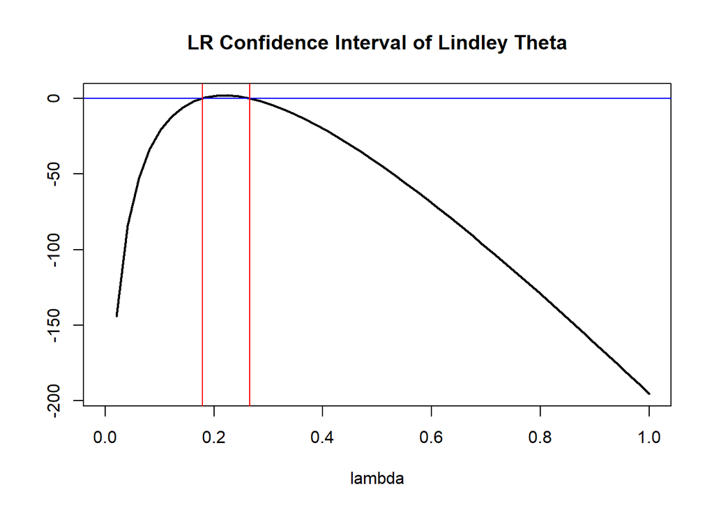

```r
xx <- seq(0,1,length=n)
S <- sum(data)
n <- length(data)
x_bar <- S / n
C <- sum(log(1+data))

loglik <- function(theta){
  n * log(theta^2 / (1 + theta)) + C - theta * S
}

l_max <- loglik(theta_mle)

fun <- function(theta){
  n * log(theta^2 / (1 + theta)) + C - theta * S - l_max + 3.841459/2
}

plot(xx, fun(xx), type = "l", lwd = 2, main = "LR Confidence Interval of Lindley Theta",
     xlab = "lambda",
     ylab = "")
abline(h=0, col = "blue")
theta_0<- uniroot(fun, interval = c(0.01, .25))$root
theta_1 <- uniroot(fun, interval = c(.25 , 1.5))$root
abline(v=c(theta_0, theta_1), col = "red")
```

```r
theta_0
```

```
[1] 0.1786273
```

```r
theta_1
```

```
[1] 0.2653359
```

3. Assuming the two confidence intervals above are valid, compare them in terms of performance and make a recommendation. Justify your recommendation.

I would recommend the LR CI for theta, as we had the correct model specification here (Lindley dist), along with the fact theta was a complex parameter. We also had a narrower CI with a LR method. CLT-based methods are more useful for large samples, and is simple computationally.